# ACA3-MC

## Analysis Challenge Assignment 3

### Author: Ming Chen

### Introduction

For the purpose of increasing college graduation rates for underpriveleged populations, I decided to create clusters that can display graduation rates and costs of different colleges and universities (especially for students in low-income families who need financial assistance).

I plan to complete the work in 4 sections:

1.Prepare data (create new arrays for selected variables,merge data, drop null and strange data, and z-score transformation)  
2.Reduce dimensions (PCA)  
3.Identify clusters (K-means)  
4.Explain the clusters

### 1. Prepare data

#### 1.1 Import and select

According to the purpose, I selected variables that are related to financial stuff and graduation.

• UNITID (used for marking the institution)  
• CURROPER (Currently Operating, used for dropping the institutions that were closed)

```python
import os
os.chdir('D:\\Learning\\CU\\Courses\\EDM\\ACA3')

import numpy as np
import pandas as pd
import matplotlib.pyplot as plt
import seaborn as sns
```

```python
# Select data
subsetcols=['UNITID','CURROPER','TUITFTE','COSTT4_A','COSTT4_P','NPT4_048_PUB','NPT4_048_PRIV','NPT4_048_PROG','PCTFLOAN','PCTPELL','C150_4_POOLED','C150_L4_POOLED','C200_4_POOLED','C200_L4_POOLED']
CSCdata=pd.read_csv("CollegeScorecard.csv",usecols=subsetcols)
CSCdata=CSCdata[CSCdata['CURROPER']==1]
CSCdata
```

|  | UNITID | CURROPER | NPT4_048_PUB | NPT4_048_PRIV | NPT4_048_PROG | COSTT4_A | COSTT4_P | TUITFTE | PCTPELL | C150_4_POOLED | C150_L4_POOLED | C200_4_POOLED | C200_L4_POOLED | PCTFLOAN |
| --- | --- | --- | --- | --- | --- | --- | --- | --- | --- | --- | --- | --- | --- | --- |
| 0 | 100654 | 1 | 12807.0 | NaN | NaN | 18888.0 | NaN | 9063.0 | 0.7115 | 0.308718 | NaN | 0.351686 | NaN | 0.8204 |
| 1 | 100663 | 1 | 12846.0 | NaN | NaN | 19990.0 | NaN | 9033.0 | 0.3505 | 0.508550 | NaN | 0.473092 | NaN | 0.5397 |
| 2 | 100690 | 1 | NaN | 7455.0 | NaN | 12300.0 | NaN | 12057.0 | 0.6839 | 0.285738 | NaN | 0.333314 | NaN | 0.7629 |
| 3 | 100706 | 1 | 15239.0 | NaN | NaN | 20306.0 | NaN | 8322.0 | 0.3281 | 0.478211 | NaN | 0.494129 | NaN | 0.4728 |
| 4 | 100724 | 1 | 12074.0 | NaN | NaN | 17400.0 | NaN | 7813.0 | 0.8265 | 0.257482 | NaN | 0.293652 | NaN | 0.8735 |
| ... | ... | ... | ... | ... | ... | ... | ... | ... | ... | ... | ... | ... | ... | ... |
| 7799 | 48285703 | 1 | NaN | NaN | NaN | NaN | NaN | NaN | NaN | NaN | NaN | NaN | NaN | NaN |
| 7800 | 48285704 | 1 | NaN | NaN | NaN | NaN | NaN | NaN | NaN | NaN | NaN | NaN | NaN | NaN |
| 7801 | 48285705 | 1 | NaN | NaN | NaN | NaN | NaN | NaN | NaN | NaN | NaN | NaN | NaN | NaN |
| 7802 | 48285706 | 1 | NaN | NaN | NaN | NaN | NaN | NaN | NaN | NaN | NaN | NaN | NaN | NaN |
| 7803 | 48285707 | 1 | NaN | NaN | NaN | NaN | NaN | NaN | NaN | NaN | NaN | NaN | NaN | NaN |

7441 rows × 14 columns

#### 1.2 Merge and drop

```python
# Merge data of same meanings for different type of school
CSCdata=CSCdata.fillna(0)
# fill nan to merge columns
CSCdata['COSTT4']=CSCdata['COSTT4_A']+CSCdata['COSTT4_P']
CSCdata['NPT4_048']=CSCdata['NPT4_048_PUB']+CSCdata['NPT4_048_PRIV']+CSCdata['NPT4_048_PROG']
CSCdata['C150']=CSCdata['C150_4_POOLED']+CSCdata['C150_L4_POOLED']
CSCdata['C200']=CSCdata['C200_4_POOLED']+CSCdata['C200_L4_POOLED']
CSCdata=CSCdata.drop(['CURROPER','COSTT4_A','COSTT4_P','NPT4_048_PUB','NPT4_048_PRIV','NPT4_048_PROG','C150_4_POOLED','C150_L4_POOLED','C200_4_POOLED','C200_L4_POOLED'],axis=1)
CSCdata
```

|  | UNITID | TUITFTE | PCTPELL | PCTFLOAN | COSTT4 | NPT4_048 | C150 | C200 |
| --- | --- | --- | --- | --- | --- | --- | --- | --- |
| 0 | 100654 | 9063.0 | 0.7115 | 0.8204 | 18888.0 | 12807.0 | 0.308718 | 0.351686 |
| 1 | 100663 | 9033.0 | 0.3505 | 0.5397 | 19990.0 | 12846.0 | 0.508550 | 0.473092 |
| 2 | 100690 | 12057.0 | 0.6839 | 0.7629 | 12300.0 | 7455.0 | 0.285738 | 0.333314 |
| 3 | 100706 | 8322.0 | 0.3281 | 0.4728 | 20306.0 | 15239.0 | 0.478211 | 0.494129 |
| 4 | 100724 | 7813.0 | 0.8265 | 0.8735 | 17400.0 | 12074.0 | 0.257482 | 0.293652 |
| ... | ... | ... | ... | ... | ... | ... | ... | ... |
| 7799 | 48285703 | 0.0 | 0.0000 | 0.0000 | 0.0 | 0.0 | 0.000000 | 0.000000 |
| 7800 | 48285704 | 0.0 | 0.0000 | 0.0000 | 0.0 | 0.0 | 0.000000 | 0.000000 |
| 7801 | 48285705 | 0.0 | 0.0000 | 0.0000 | 0.0 | 0.0 | 0.000000 | 0.000000 |
| 7802 | 48285706 | 0.0 | 0.0000 | 0.0000 | 0.0 | 0.0 | 0.000000 | 0.000000 |
| 7803 | 48285707 | 0.0 | 0.0000 | 0.0000 | 0.0 | 0.0 | 0.000000 | 0.000000 |

7441 rows × 8 columns

```python
# Drop 0 data
CSCdata=CSCdata[(CSCdata['TUITFTE']>0)&(CSCdata['PCTPELL']>0)&(CSCdata['PCTFLOAN']>0)&(CSCdata['COSTT4']>0)&(CSCdata['NPT4_048']>0)&(CSCdata['C150']>0)&(CSCdata['C200']>0)]
CSCdata
```

|  | UNITID | TUITFTE | PCTPELL | PCTFLOAN | COSTT4 | NPT4_048 | C150 | C200 |
| --- | --- | --- | --- | --- | --- | --- | --- | --- |
| 0 | 100654 | 9063.0 | 0.7115 | 0.8204 | 18888.0 | 12807.0 | 0.308718 | 0.351686 |
| 1 | 100663 | 9033.0 | 0.3505 | 0.5397 | 19990.0 | 12846.0 | 0.508550 | 0.473092 |
| 2 | 100690 | 12057.0 | 0.6839 | 0.7629 | 12300.0 | 7455.0 | 0.285738 | 0.333314 |
| 3 | 100706 | 8322.0 | 0.3281 | 0.4728 | 20306.0 | 15239.0 | 0.478211 | 0.494129 |
| 4 | 100724 | 7813.0 | 0.8265 | 0.8735 | 17400.0 | 12074.0 | 0.257482 | 0.293652 |
| ... | ... | ... | ... | ... | ... | ... | ... | ... |
| 7365 | 482635 | 18072.0 | 0.6349 | 0.7870 | 24919.0 | 19516.0 | 0.291900 | 0.214800 |
| 7367 | 482653 | 17432.0 | 0.4802 | 0.5870 | 25202.0 | 19228.0 | 0.224700 | 0.258100 |
| 7368 | 482662 | 15865.0 | 0.5855 | 0.7155 | 21999.0 | 16418.0 | 0.290300 | 0.227300 |
| 7370 | 482680 | 4149.0 | 0.3793 | 0.3858 | 16525.0 | 14385.0 | 0.259700 | 0.315000 |
| 7378 | 483045 | 889.0 | 0.6738 | 0.2912 | 8532.0 | 2735.0 | 0.306200 | 0.389200 |

4991 rows × 8 columns

```python
CSCdata.describe()
```

|  | UNITID | TUITFTE | PCTPELL | PCTFLOAN | COSTT4 | NPT4_048 | C150 | C200 |
| --- | --- | --- | --- | --- | --- | --- | --- | --- |
| count | 4991.000000 | 4991.000000 | 4991.000000 | 4991.000000 | 4991.000000 | 4991.000000 | 4991.000000 | 4991.000000 |
| mean | 258462.972951 | 9746.690042 | 0.513575 | 0.573303 | 23133.161491 | 14492.996394 | 0.523267 | 0.548456 |
| std | 122704.451650 | 7217.799687 | 0.209030 | 0.235843 | 11289.619285 | 6828.342143 | 0.231900 | 0.230827 |
| min | 100654.000000 | 2.000000 | 0.031300 | 0.000600 | 5285.000000 | 156.000000 | 0.019204 | 0.009693 |
| 25% | 164243.000000 | 4687.000000 | 0.353550 | 0.423250 | 14925.000000 | 9184.500000 | 0.335578 | 0.362082 |
| 50% | 210890.000000 | 8867.000000 | 0.491100 | 0.606800 | 20576.000000 | 13974.000000 | 0.543258 | 0.561613 |
| 75% | 408389.500000 | 13065.000000 | 0.674350 | 0.750200 | 27395.500000 | 19120.000000 | 0.708342 | 0.729886 |
| max | 483045.000000 | 155643.000000 | 1.000000 | 1.000000 | 76806.000000 | 71823.000000 | 1.000000 | 1.000000 |

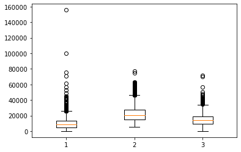

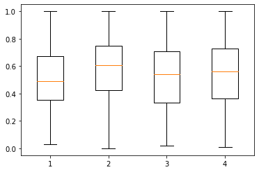

|  | UNITID | TUITFTE | PCTPELL | PCTFLOAN | COSTT4 | NPT4_048 | C150 | C200 |
| --- | --- | --- | --- | --- | --- | --- | --- | --- |
| 0 | 100654 | 9063.0 | 0.7115 | 0.8204 | 18888.0 | 12807.0 | 0.308718 | 0.351686 |
| 1 | 100663 | 9033.0 | 0.3505 | 0.5397 | 19990.0 | 12846.0 | 0.508550 | 0.473092 |
| 2 | 100690 | 12057.0 | 0.6839 | 0.7629 | 12300.0 | 7455.0 | 0.285738 | 0.333314 |
| 3 | 100706 | 8322.0 | 0.3281 | 0.4728 | 20306.0 | 15239.0 | 0.478211 | 0.494129 |
| 4 | 100724 | 7813.0 | 0.8265 | 0.8735 | 17400.0 | 12074.0 | 0.257482 | 0.293652 |
| ... | ... | ... | ... | ... | ... | ... | ... | ... |
| 7365 | 482635 | 18072.0 | 0.6349 | 0.7870 | 24919.0 | 19516.0 | 0.291900 | 0.214800 |
| 7367 | 482653 | 17432.0 | 0.4802 | 0.5870 | 25202.0 | 19228.0 | 0.224700 | 0.258100 |
| 7368 | 482662 | 15865.0 | 0.5855 | 0.7155 | 21999.0 | 16418.0 | 0.290300 | 0.227300 |
| 7370 | 482680 | 4149.0 | 0.3793 | 0.3858 | 16525.0 | 14385.0 | 0.259700 | 0.315000 |
| 7378 | 483045 | 889.0 | 0.6738 | 0.2912 | 8532.0 | 2735.0 | 0.306200 | 0.389200 |

4646 rows × 8 columns

```python
# Check if there are strange values that can affect PCA and K-means
plt.boxplot([CSCdata['TUITFTE'],CSCdata['COSTT4'],CSCdata['NPT4_048']])
plt.show()
plt.boxplot([CSCdata['PCTPELL'],CSCdata['PCTFLOAN'],CSCdata['C150'],CSCdata['C200']])
plt.show()
# Drop strange values (>Q3 + 1.5*(Q3 - Q1)or<Q1 - 1.5*(Q3 - Q1),according to boxplot, we do not have strange values that under the low whisker, so just pick out the extremely larger ones)
upT=13065+1.5*(13065-4687)
upC=27395.5+1.5*(27395.5-14925)
upN=19120+1.5*(19120-9184.5)
CSCdata=CSCdata[(CSCdata['TUITFTE']<upT)&(CSCdata['COSTT4']<upC)&(CSCdata['NPT4_048']<upN)]
CSCdata
```

#### 1.3 z-score transformation

```python
# Create new arrays without UNITID
CSC=CSCdata.drop('UNITID',axis=1)
CSC
from sklearn import preprocessing
CSC_scale=preprocessing.scale(CSC)
# transform data back to dataframe
CSC=pd.DataFrame(CSC_scale,columns=["TUITFTE","PCTPELL","PCTFLOAN","COSTT4","NPT4_048","C150","C200"])
CSC
```

|  | TUITFTE | PCTPELL | PCTFLOAN | COSTT4 | NPT4_048 | C150 | C200 |
| --- | --- | --- | --- | --- | --- | --- | --- |
| 0 | 0.077177 | 0.899340 | 1.025313 | -0.267081 | -0.186329 | -0.869650 | -0.796632 |
| 1 | 0.071559 | -0.903678 | -0.151793 | -0.137745 | -0.180042 | 0.001741 | -0.266958 |
| 2 | 0.637897 | 0.761492 | 0.784189 | -1.040279 | -1.049015 | -0.969858 | -0.876783 |
| 3 | -0.061598 | -1.015555 | -0.432336 | -0.100658 | 0.205684 | -0.130553 | -0.175178 |
| 4 | -0.156924 | 1.473709 | 1.247987 | -0.441720 | -0.304481 | -1.093073 | -1.049823 |
| ... | ... | ... | ... | ... | ... | ... | ... |
| 4641 | 1.764393 | 0.516761 | 0.885252 | 0.440745 | 0.895092 | -0.942989 | -1.393837 |
| 4642 | 1.644533 | -0.255890 | 0.046558 | 0.473959 | 0.848669 | -1.236023 | -1.204928 |
| 4643 | 1.351063 | 0.270032 | 0.585419 | 0.098040 | 0.395727 | -0.949966 | -1.339302 |
| 4644 | -0.843122 | -0.759836 | -0.797167 | -0.544414 | 0.068028 | -1.083401 | -0.956684 |
| 4645 | -1.453659 | 0.711047 | -1.193869 | -1.482509 | -1.809830 | -0.880632 | -0.632964 |

4646 rows × 7 columns

### 2. Reduce dimensions

```python
# PCA
from sklearn.decomposition import PCA
pcatry=PCA(n_components=7)
pcatry.fit(CSC)

print("The principal components are:")
print(pcatry.components_)
print("The explained variances are:")
print(pcatry.explained_variance_)
```

```
The principal components are:
[[ 0.43564082  0.16395264  0.42035648  0.42858889  0.46406417  0.33747953
   0.30610555]
 [-0.26449754  0.05627299 -0.06800901 -0.33083524 -0.25184721  0.59468101
   0.62906653]
 [ 0.13173503 -0.81079509 -0.43467492  0.29947982  0.0850974   0.14560656
   0.13484776]
 [ 0.66882194 -0.21121583  0.30862963 -0.23587866 -0.5964318   0.00818455
  -0.03709742]
 [ 0.5233626   0.36317079 -0.66758799 -0.3052848   0.23256883  0.02747659
   0.02197297]
 [ 0.00646328  0.3681668  -0.29688924  0.68421141 -0.5511806   0.01315802
   0.06441872]
 [-0.04038608  0.02263329 -0.02576265  0.01373472 -0.01888538  0.71432885
  -0.69741091]]
The explained variances are:
[3.17506815 1.62856676 1.2605598  0.38947654 0.31941539 0.15856739
 0.06985297]
```

[output not shown]

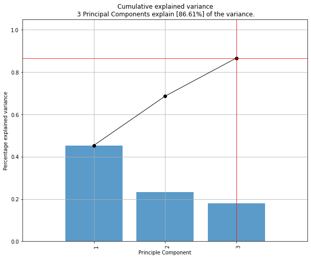

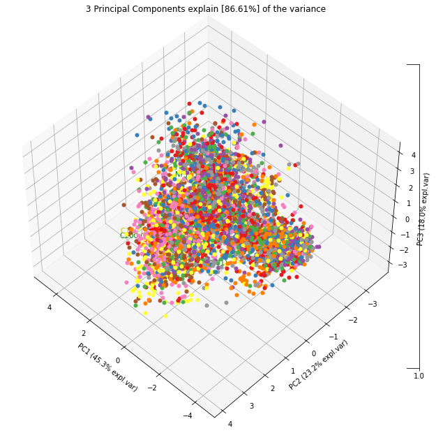

```python
from pca import pca
# According to the explained variances, 3 PCs are enough.
model=pca(n_components=3)
results=model.fit_transform(CSC)
fig,ax=model.plot()
fig,ax=model.biplot3d(n_feat=7,legend=False)
```

### 3. Identify clusters

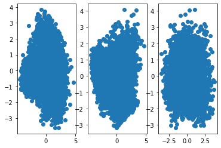

```python
pca3=PCA(n_components=3)
pca3.fit(CSC)
CSCr=pcatry.transform(CSC)

fig,ax=plt.subplots(1,3)
ax[0].scatter(CSCr[:,0],CSCr[:,1])
ax[1].scatter(CSCr[:,0],CSCr[:,2])
ax[2].scatter(CSCr[:,1],CSCr[:,2])
```

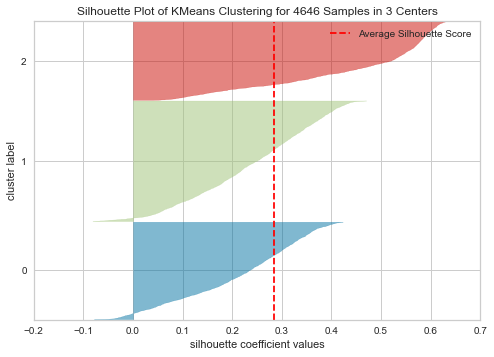

```
Silhouette Score: 0.2840454845158921
```

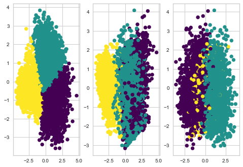

```python
# K-means to find the clusters
from sklearn.cluster import KMeans
# Try 3 clusters
kmeans3=KMeans(n_clusters=3)
kmeans3.fit(CSCr)
clusters3=kmeans3.predict(CSCr)
# Check the efficiency of kmeans3
from yellowbrick.cluster import silhouette_visualizer
silhouette_visualizer(kmeans3,CSCr,colors='yellowbrick')
from sklearn.metrics import silhouette_score
silhouetteScore3=silhouette_score(CSCr,clusters3,metric='euclidean')
print('Silhouette Score:',silhouetteScore3)

fig,ax=plt.subplots(1,3)
ax[0].scatter(CSCr[:,0],CSCr[:,1],c=clusters3,cmap='viridis')
ax[1].scatter(CSCr[:,0],CSCr[:,2],c=clusters3,cmap='viridis')
ax[2].scatter(CSCr[:,1],CSCr[:,2],c=clusters3,cmap='viridis')
```

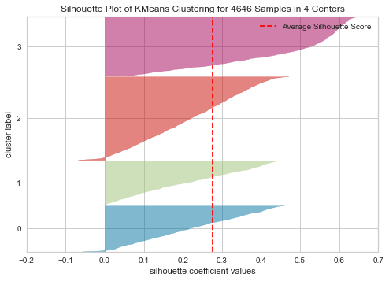

```
Silhouette Score: 0.2753411102266643
```

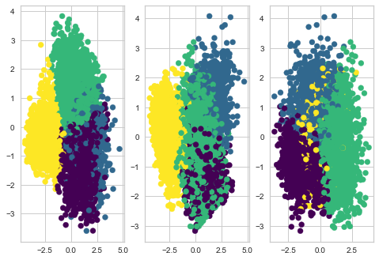

```python
# Try 4 clusters
kmeans4=KMeans(n_clusters=4)
kmeans4.fit(CSCr)
clusters4=kmeans4.predict(CSCr)
# Check the efficiency of kmeans4
from yellowbrick.cluster import silhouette_visualizer
silhouette_visualizer(kmeans4,CSCr,colors='yellowbrick')
from sklearn.metrics import silhouette_score
silhouetteScore4=silhouette_score(CSCr,clusters4,metric='euclidean')
print('Silhouette Score:',silhouetteScore4)

fig,ax=plt.subplots(1,3)
ax[0].scatter(CSCr[:,0],CSCr[:,1],c=clusters4,cmap='viridis')
ax[1].scatter(CSCr[:,0],CSCr[:,2],c=clusters4,cmap='viridis')
ax[2].scatter(CSCr[:,1],CSCr[:,2],c=clusters4,cmap='viridis')
```

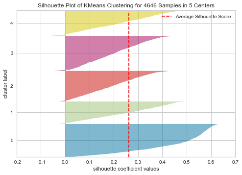

```
Silhouette Score: 0.262492490989462
```

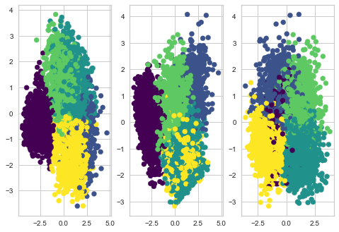

```python
# Try 5 clusters
kmeans5=KMeans(n_clusters=5)
kmeans5.fit(CSCr)
clusters5=kmeans5.predict(CSCr)
# Check the efficiency of kmeans5
from yellowbrick.cluster import silhouette_visualizer
silhouette_visualizer(kmeans5,CSCr,colors='yellowbrick')
from sklearn.metrics import silhouette_score
silhouetteScore5=silhouette_score(CSCr,clusters5,metric='euclidean')
print('Silhouette Score:',silhouetteScore5)

fig,ax=plt.subplots(1,3)
ax[0].scatter(CSCr[:,0],CSCr[:,1],c=clusters5,cmap='viridis')
ax[1].scatter(CSCr[:,0],CSCr[:,2],c=clusters5,cmap='viridis')
ax[2].scatter(CSCr[:,1],CSCr[:,2],c=clusters5,cmap='viridis')
```

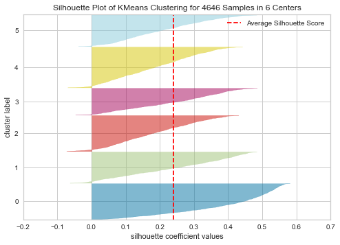

```
Silhouette Score: 0.24033544735870904
```

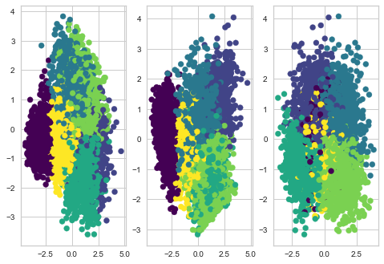

```python
# Try 6 clusters
kmeans6=KMeans(n_clusters=6)
kmeans6.fit(CSCr)
clusters6=kmeans6.predict(CSCr)
# Check the efficiency of kmeans6
from yellowbrick.cluster import silhouette_visualizer
silhouette_visualizer(kmeans6,CSCr,colors='yellowbrick')
from sklearn.metrics import silhouette_score
silhouetteScore6=silhouette_score(CSCr,clusters6,metric='euclidean')
print('Silhouette Score:',silhouetteScore6)

fig,ax=plt.subplots(1,3)
ax[0].scatter(CSCr[:,0],CSCr[:,1],c=clusters6,cmap='viridis')
ax[1].scatter(CSCr[:,0],CSCr[:,2],c=clusters6,cmap='viridis')
ax[2].scatter(CSCr[:,1],CSCr[:,2],c=clusters6,cmap='viridis')
```

```python
# It seems that clusters5 is the clearest (for explanation), which separates the data from 3 dimensions.
# Then create the cluster labels corresponding to UNITID

CSCdataCluster=CSCdata.copy(deep=True)
CSCdataCluster['cluster']=clusters5
CSCdataCluster
```

|  | UNITID | TUITFTE | PCTPELL | PCTFLOAN | COSTT4 | NPT4_048 | C150 | C200 | cluster |
| --- | --- | --- | --- | --- | --- | --- | --- | --- | --- |
| 0 | 100654 | 9063.0 | 0.7115 | 0.8204 | 18888.0 | 12807.0 | 0.308718 | 0.351686 | 4 |
| 1 | 100663 | 9033.0 | 0.3505 | 0.5397 | 19990.0 | 12846.0 | 0.508550 | 0.473092 | 3 |
| 2 | 100690 | 12057.0 | 0.6839 | 0.7629 | 12300.0 | 7455.0 | 0.285738 | 0.333314 | 4 |
| 3 | 100706 | 8322.0 | 0.3281 | 0.4728 | 20306.0 | 15239.0 | 0.478211 | 0.494129 | 3 |
| 4 | 100724 | 7813.0 | 0.8265 | 0.8735 | 17400.0 | 12074.0 | 0.257482 | 0.293652 | 4 |
| ... | ... | ... | ... | ... | ... | ... | ... | ... | ... |
| 7365 | 482635 | 18072.0 | 0.6349 | 0.7870 | 24919.0 | 19516.0 | 0.291900 | 0.214800 | 4 |
| 7367 | 482653 | 17432.0 | 0.4802 | 0.5870 | 25202.0 | 19228.0 | 0.224700 | 0.258100 | 4 |
| 7368 | 482662 | 15865.0 | 0.5855 | 0.7155 | 21999.0 | 16418.0 | 0.290300 | 0.227300 | 4 |
| 7370 | 482680 | 4149.0 | 0.3793 | 0.3858 | 16525.0 | 14385.0 | 0.259700 | 0.315000 | 0 |
| 7378 | 483045 | 889.0 | 0.6738 | 0.2912 | 8532.0 | 2735.0 | 0.306200 | 0.389200 | 0 |

4646 rows × 9 columns

### 4. Explain the clusters

To explain the clusters, there still two things to be done:

1. List the loadings of PCs, so that it can display what each PC represents.
2. Plot the classified scatter with labels that can clearly show the meanings for clusters.

```python
# Loadings
CSCloadings=pd.DataFrame(pca3.components_,columns=list(CSC.columns))
CSCloadings
```

|  | TUITFTE | PCTPELL | PCTFLOAN | COSTT4 | NPT4_048 | C150 | C200 |
| --- | --- | --- | --- | --- | --- | --- | --- |
| 0 | 0.435641 | 0.163953 | 0.420356 | 0.428589 | 0.464064 | 0.337480 | 0.306106 |
| 1 | -0.264498 | 0.056273 | -0.068009 | -0.330835 | -0.251847 | 0.594681 | 0.629067 |
| 2 | 0.131735 | -0.810795 | -0.434675 | 0.299480 | 0.085097 | 0.145607 | 0.134848 |

##### Explain:

According to the loadings showed above:

PC1 mainly explains the variables of average tuition fee, average cost, and average net price for low-income families, which can represent the average prices of schools. PC2 mainly explains the variables of completion rate within 150/200 percent of the expected time, which can represent the graduation rates of schools.  
PC3 mainly explains the share of students who received federal loans/Pell Grants, which can represent the support for student of schools.

Besides, PC1 also explains a large part of the share of students who received federal loans, it actually makes sense because higher price means higher demends of support. However, PC1 explains little for the share of Pell Grants received, which is an important measure of the access a school provides to low-income students (according to FullDataDocumentation for the dataset). So PC3 is a better component to explain the support for those low-income students.

In conclusion:  
High PC1 scores mean high price of schools.  
High PC2 scores mean high graduation rates.  
While high PC3 scores mean low support for low-income students.

```python
# Clusters
CSCrp=CSCr[:,0:3]
CSCrp=pd.DataFrame(CSCrp,columns=["Price","Graduation","Support"])
CSCrp["Clusters"]=clusters5
CSCrp
```

|  | Price | Graduation | Support | Clusters |
| --- | --- | --- | --- | --- |
| 0 | -0.126211 | -0.922548 | -1.494584 | 4 |
| 1 | -0.404511 | -0.135441 | 0.715786 | 3 |
| 2 | -0.795976 | -0.699161 | -1.534509 | 4 |
| 3 | -0.420445 | -0.217789 | 0.947944 | 3 |
| 4 | -0.323006 | -1.048057 | -2.216939 | 4 |
| ... | ... | ... | ... | ... |
| 4641 | 1.084865 | -2.306637 | -0.688449 | 4 |
| 4642 | 0.505046 | -2.316098 | 0.275585 | 4 |
| 4643 | 0.374035 | -1.921506 | -0.551312 | 4 |
| 4644 | -1.687202 | -0.848657 | 0.407502 | 0 |
| 4645 | -2.984759 | 0.530091 | -1.060639 | 0 |

4646 rows × 4 columns

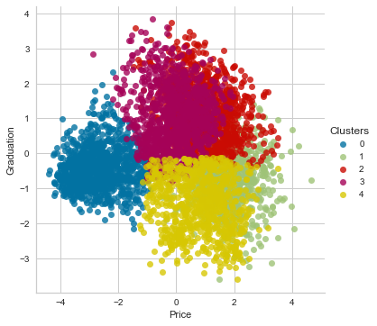

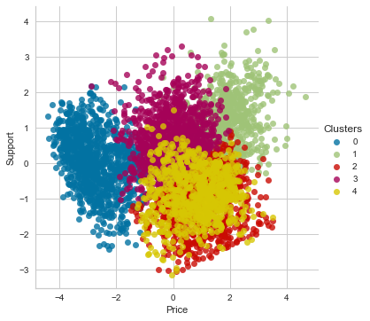

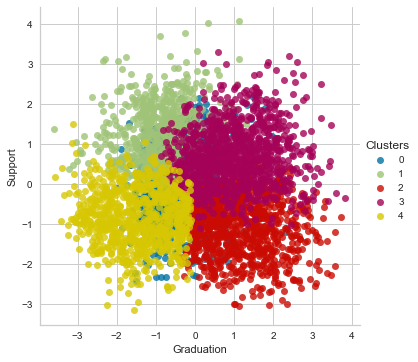

```python
sns.lmplot(data=CSCrp,x='Price',y='Graduation',hue='Clusters',
           fit_reg=False, legend=True, legend_out=True)
sns.lmplot(data=CSCrp,x='Price',y='Support',hue='Clusters',
           fit_reg=False, legend=True, legend_out=True)
sns.lmplot(data=CSCrp,x='Graduation',y='Support',hue='Clusters',
           fit_reg=False, legend=True, legend_out=True)
```

##### Explain:

According to the figures showed above,we can identify 5 clusters from 3 dimensions:

Cluster0(blue): low price, middle support, middle graduation  
Cluster1(green): relative high price, low support, low graduation  
Cluster2(red): middle price, high support, high graduation  
Cluster3(purple): middle price, low support, high graduation  
Cluster4(yellow): middle price, high support, low graduation

The results indicate that, to increase college graduation rates for underpriveleged populations, we may better recommend schools of cluster2 and cluster0 to those low-income studets. Cluster2 schools have high graduation rates, and they provide high supports for low-income students in spite of middle price for attending schools. Cluster0 schools have middel graduation rates, but the low price and middle support of the schools are appropriate for low-income students.